# Heart Disease Project

Anna M

2023-08-20

The Heart Disease Dataset from Kaggle will be used for exploratory data analysis (EDA). As this data set is already cleaned, EDA will focus on investigating and visualizing the attributes of this data set. This project will investigate whether there is a correlation between heart disease and other parameters in this data set.

Dataset downloaded

```r
heart <- read.csv("heart.csv")
```

Brief overview of correlation of variables

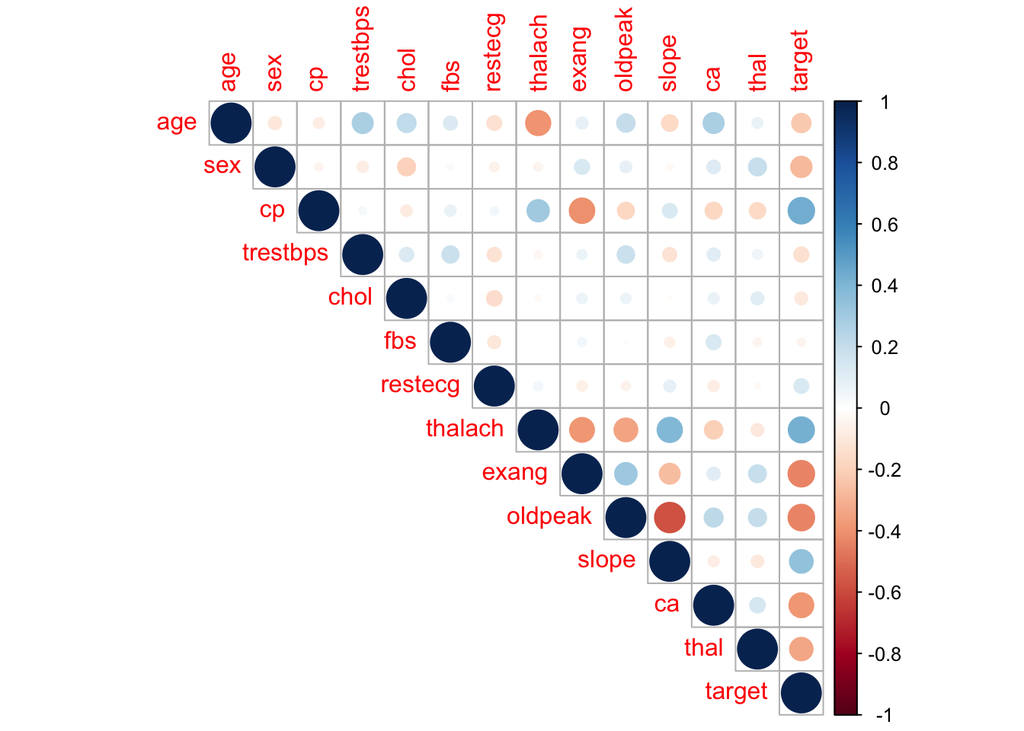

```r
corrplot(cor(heart), type="upper")
```

Identify variables in dataset

```r
ls()
```

```
## [1] "heart"
```

```r
ls(heart)
```

```
##  [1] "age"      "ca"       "chol"     "cp"       "exang"    "fbs"
##  [7] "oldpeak"  "restecg"  "sex"      "slope"    "target"   "thal"
## [13] "thalach"  "trestbps"
```

Categorical variables changed from numeric values to string values

```r
heart$sex[heart$sex == 0] = "female"
heart$sex[heart$sex == 1] = "male"
heart$cp[heart$cp == 0] = "typical angina"
heart$cp[heart$cp == 1] = "atypical angina"
heart$cp[heart$cp == 2] = "non-anginal pain"
heart$cp[heart$cp == 3] = "asymptomatic"
##trestbps does not need to be changed as it shows resting blood pressure (unique)
##chol does not need to be changed as it shows cholesterol level (unique)
heart$fbs[heart$fbs == 0] = "blood sugar = or < 120mg/dl"
heart$fbs[heart$fbs == 1] = "blood sugar > 120mg/dl"
heart$restecg[heart$restecg == 0] = "normal ECG"
heart$restecg[heart$restecg == 1] = "ST-T wave abnormality"
heart$restecg[heart$restecg == 2] = "left ventricular hypertrophy"
##thalach does not need to be changed as it shows maximum heart rate (unique)
heart$exang[heart$exang == 0] = "no"
heart$exang[heart$exang == 1] = "yes"
##oldpeak does not need to be changed as it shows ST depression (unique)
heart$slope[heart$slope == 0] = "upsloping"
heart$slope[heart$slope == 1] = "flat"
heart$slope[heart$slope == 2] = "downsloping"
##ca does not need to be changed as it shows number of major vessels (numeric)
heart$thal[heart$thal == 1] = "normal"
heart$thal[heart$thal == 2] = "fixed defect"
heart$thal[heart$thal == 3] = "reversable defect"
```

We will use “target1” to keep have both the numeric value of target and the categorical value of target1.

```r
heart$target1[heart$target == 0] = "no"
heart$target1[heart$target == 1] = "yes"
```

Q: What is proportion of sample population with heart disease?

```r
##Proportion table
prop.table(table(heart$target1))
```

```
##
##        no       yes
## 0.4868293 0.5131707
```

```r
##Proportion table with result rounded to two decimal places
round(prop.table(table(heart$target1)), 2)
```

```
##
##   no  yes
## 0.49 0.51
```

Q: What subpopulation is heart disease most prevalent in?

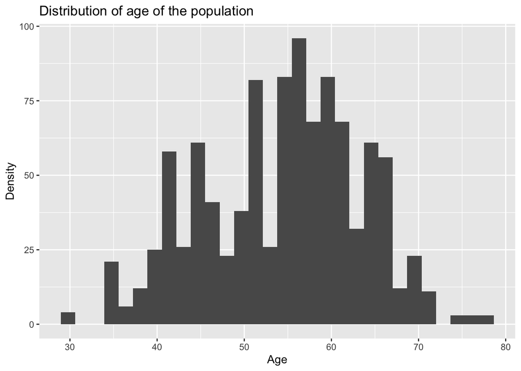

```r
##Distribution of sample
ggplot(heart, aes(x=age)) +
  geom_histogram() +
  ggtitle("Distribution of age of the population") +
  xlab("Age") +
  ylab("Density")
```

```r
##Min and max age ranges
min(heart$age)
```

```
## [1] 29
```

```r
max(heart$age)
```

```
## [1] 77
```

We will look at the range of ages from 29-77. Now we separate age groups into 4-year sections.

```r
##The cut function was not including lowest group (29-33) and instead putting
##putting this value at the end of the list with NA, but this was fixed by adding
#the last argument.
heart$age_group = cut(heart$age, breaks = seq(29,77,4), include.lowest = TRUE)
```

Now, we can find the number of people with heart disease for each age group.

```r
##NB: we are using target here (numeric), not target1 (character) because
##summarise cannot take character vectors.

HD_by_age = heart %>%
  group_by(age_group) %>%
  summarise(heart_disease = sum(target))

HD_by_age
```

```
## # A tibble: 12 × 2
##    age_group heart_disease
##    <fct>             <int>
##  1 [29,33]               4
##  2 (33,37]              20
##  3 (37,41]              50
##  4 (41,45]              82
##  5 (45,49]              43
##  6 (49,53]              87
##  7 (53,57]              80
##  8 (57,61]              52
##  9 (61,65]              53
## 10 (65,69]              35
## 11 (69,73]              14
## 12 (73,77]               6
```

We can visualise this with a barplot.

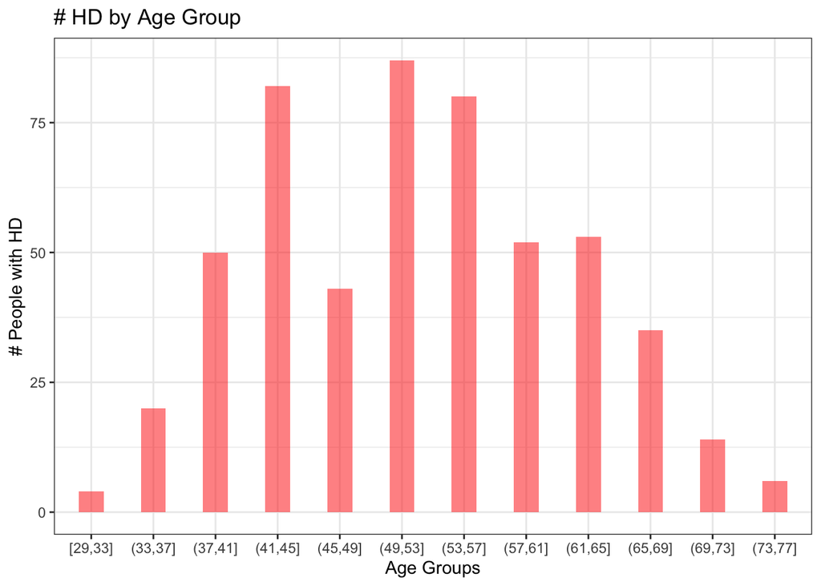

```r
HD_by_age %>%
  ggplot(aes(x = age_group, y = heart_disease)) +
  geom_bar(stat = "identity", fill = "red", alpha = .5, width = .4) +
  xlab("Age Groups") +
  ylab("# People with HD") +
  ggtitle("# HD by Age Group") +
  theme_bw()
```

This is a good visualisation, but does not show the relative rate of HD. We need to find the proportion of people with HD by age group, as our sample does not include as many people with ages below 30 or above 70.

```r
prop_in_age <- heart %>%
  group_by(age_group) %>%
  summarise(HD_prop = round(sum(target)/n(), 3)*100)

prop_in_age
```

```
## # A tibble: 12 × 2
##    age_group HD_prop
##    <fct>       <dbl>
##  1 [29,33]     100
##  2 (33,37]      74.1
##  3 (37,41]      72.5
##  4 (41,45]      72.6
##  5 (45,49]      53.1
##  6 (49,53]      67.4
##  7 (53,57]      44.7
##  8 (57,61]      28.6
##  9 (61,65]      40.8
## 10 (65,69]      45.5
## 11 (69,73]      56
## 12 (73,77]      66.7
```

We can visualise this with a barplot.

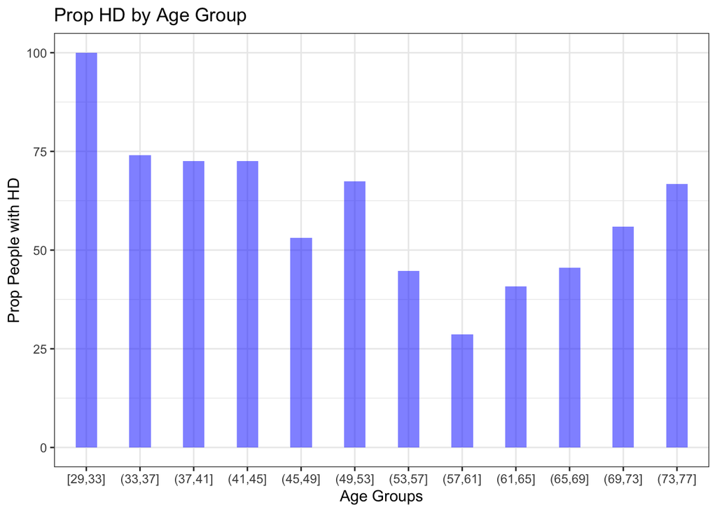

```r
prop_in_age %>%
  ggplot(aes(x = age_group, y = HD_prop)) +
  geom_bar(stat = "identity", fill = "blue", alpha = .5, width = .4) +
  xlab("Age Groups") +
  ylab("Prop People with HD") +
  ggtitle("Prop HD by Age Group") +
  theme_bw()
```

100% of people 29-33 have HD. This is not representative of real life, so this dataset is not a representative sample. Thus, we cannot infer anything about how age contributes to HD from this dataset.

#### Exploring Variable Relationships: Sex

Q: What is proportion of sample population with HD by sex?

```r
prop.table(table(heart$sex))
```

```
##
##    female      male
## 0.3043902 0.6956098
```

```r
round(prop.table(table(heart$sex)), 2)
```

```
##
## female   male
##    0.3    0.7
```

Q: What is the proportion of males vs females with HD?

```r
round(prop.table(table(heart$sex, heart$target1)), 2)
```

```
##
##            no  yes
##   female 0.08 0.22
##   male   0.40 0.29
```

We find that the female proportion of HD is much higher than male. This could be due to females having a lower sample overall, indicating a slight bias towards a sample of more women who have HD.

#### Exploring Variable Relationships: Slope of Peak Exercise

First, I need to understand what this variable represents.

An ST slope shifts relative to exercise-induced increments in HR. Importance: The ST/HR slope has been proposed as a more accurate ECG criterion for diagnosing significant coronary artery disease.

- Upwards slope = normal ST during exercise
- Flat/downwards slope = may indicate coronary ischemia

To see this represented in our sample data, we will look at how ST slope relates to HR incidence. Since we are using yes/no, target1 (categorical) was used. To get the barplot side by side instead of stacked, dodge was used.

- slope = 0 is upwards
- slope = 1 is flat
- slope = 2 is downwards

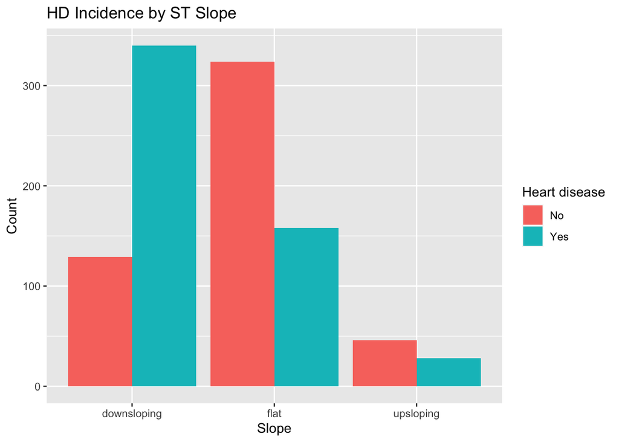

```r
ggplot(heart, aes(x = slope, fill = target1)) +
  geom_bar(position = "dodge") +
  xlab("Slope") +
  ylab("Count") +
  ggtitle("HD Incidence by ST Slope") +
  scale_fill_discrete(name = "Heart disease", labels = c("No", "Yes"))
```

From this, we see that those with downsloping ST slopes are most likely to have higher changes of HD compared with flat or upwards slope.

Now, let’s look at the above proportions by sex.

```r
male_data = heart[heart$sex=="male",]
female_data = heart[heart$sex=="female",]

##The comma at the end (row, column) means that we are looking at rows
##have "male" in all the entire column (hence it is left blank)
```

Let’s visualise this with a barplot (MALES).

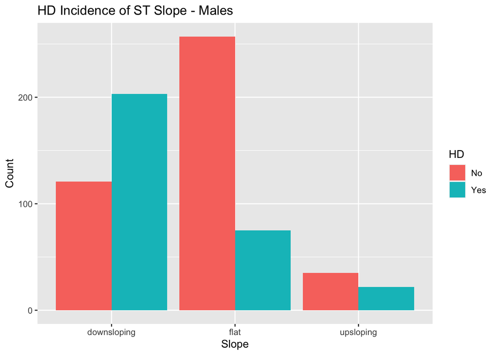

```r
ggplot(male_data, aes(x = slope, fill = target1)) +
  geom_bar(position = "dodge") +
  xlab("Slope") +
  ylab("Count") +
  ggtitle("HD Incidence of ST Slope - Males") +
  scale_fill_discrete(name = "HD", labels = c("No", "Yes"))
```

Let’s visualise this with a barplot (FEMALES).

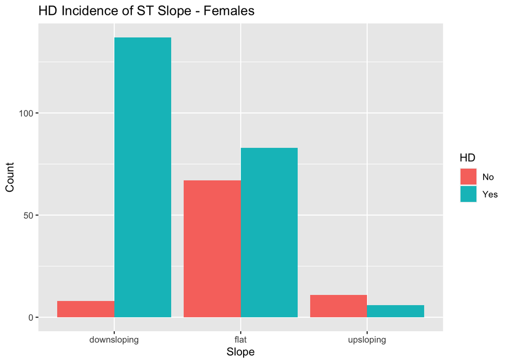

```r
ggplot(female_data, aes(x = slope, fill = target1)) +
  geom_bar(position = "dodge") +
  xlab("Slope") +
  ylab("Count") +
  ggtitle("HD Incidence of ST Slope - Females") +
  scale_fill_discrete(name = "HD", labels = c("No", "Yes"))
```

From this, we see that the proportion of women who have downsloping ST is much higher than the males proportion for this group. Additionally, compared to the original graph (not grouped by sex), the male trend follows this original graph whereas the female population is very different. As the female population is much less, it shifts the overall data pattern less, so it makes sense the overall data reflects the male pattern of HD incidence by type more.

#### Exploring Variable Relationships: Number of Major Vessels

We can use a mosaic plot to visualise the differences in HD by number of major vessels.

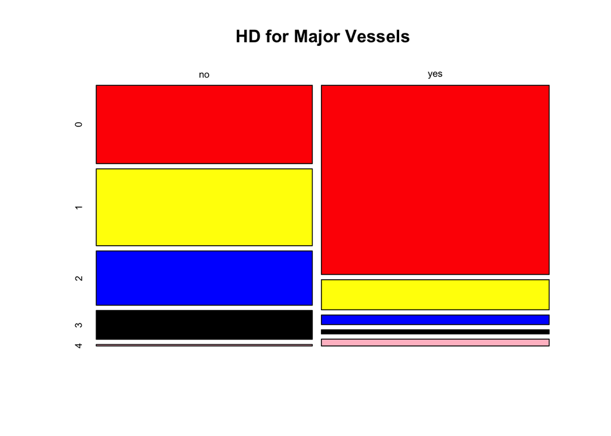

```r
mosaicplot(table(heart$target1, heart$ca), col = c("red", "yellow", "blue", "black", "pink"),
           main = "HD for Major Vessels")
```

We see that almost double the amount of people who have no major vessel have heart disease. In general, very few people have 4 major vessels.

We can visualise this by sex.

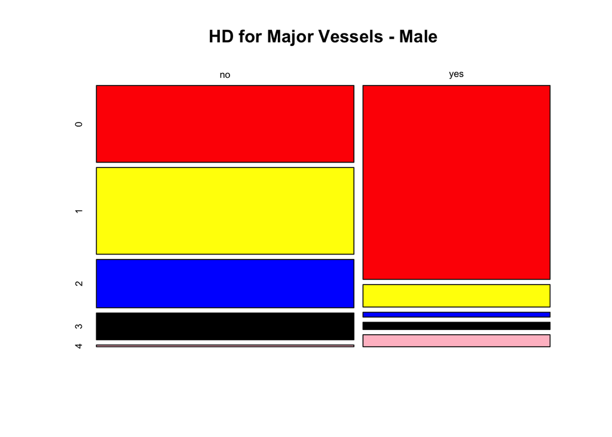

```r
mosaicplot(table(male_data$target1, male_data$ca), col = c("red", "yellow", "blue", "black", "pink"),
           main = "HD for Major Vessels - Male")
```

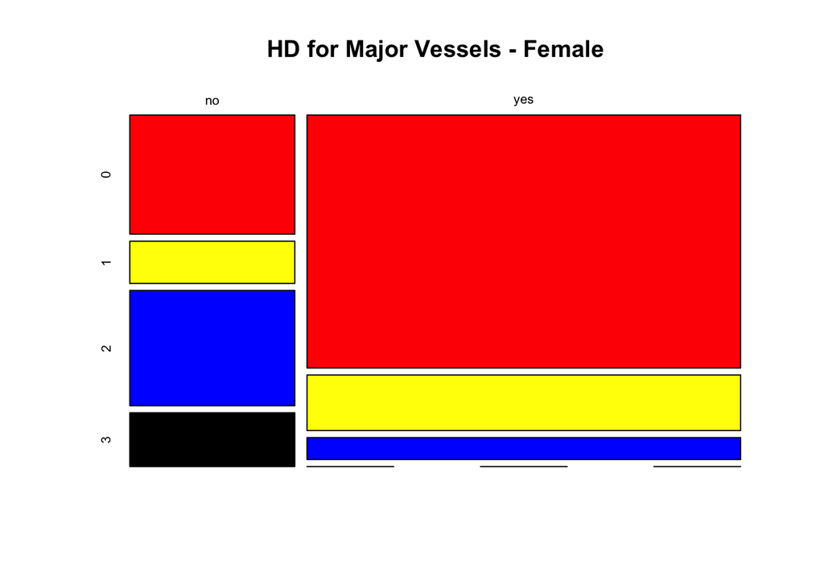

```r
mosaicplot(table(female_data$target1, female_data$ca), col = c("red", "yellow", "blue", "black", "pink"),
           main = "HD for Major Vessels - Female")
```

We find that both male and female subpopulations reflect the overall data.

#### Exploring Variable Relationships: ST Depression by Exercise

First, we will look at the distribution of ST depression by HD incidence.

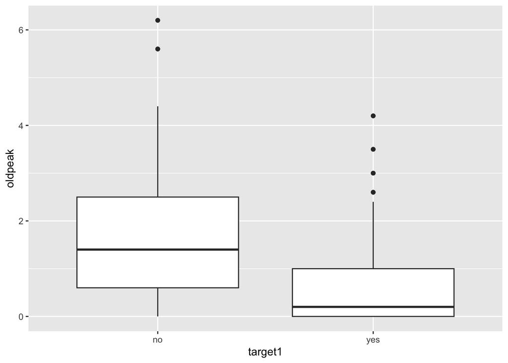

```r
ggplot(heart, aes(x = target1, y = oldpeak)) +
  geom_boxplot()
```

Q: Does this depression change by age? Does this have an impact on HD?

[figure not shown]

```r
ggplot(heart, aes(x = age, y = oldpeak, color = target1)) +
  geom_point(alpha = 0.3) +
  labs(color = "Heart Disease State") +
  xlab("Age") +
  ylab("ST Depression") +
  ggtitle("Age vs Resting Blood Pressure Separated by Heart Condition") +
  guides(size = FALSE)
```

We see that there is no clear relationship ebtween age and ST depresison.

#### Exploring Variable Relationships: Resting Blood Pressure

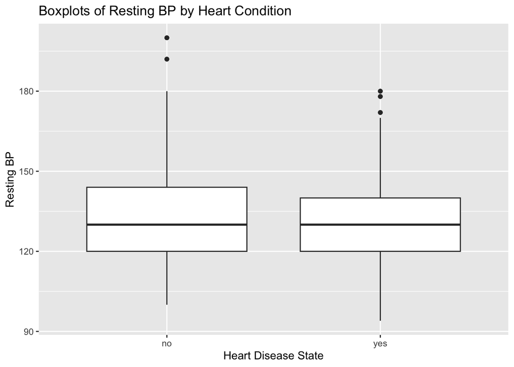

```r
ggplot(heart, aes(x = target1, y = trestbps)) +
  geom_boxplot() +
  xlab("Heart Disease State") +
  ylab("Resting BP") +
  ggtitle("Boxplots of Resting BP by Heart Condition")
```

Medians of these boxplots are similar. We can interrogate this relationship further by looking at ST Depression.

[figure not shown]

```r
ggplot(heart, aes(x = age, y = trestbps, color = target1, size = factor(oldpeak))) +
  geom_point(alpha = 0.3) +
  xlab("Heart Disease State") +
  ylab("Resting BP") +
  ggtitle("Boxplots of Resting BP by Heart Condition") +
  guides(size = FALSE)
```

From this, we see that resting blood pressure is low (< 100), heart disease cases are higher than no heart disease cases. Additionally, most dots are red meaning that more people with ST depression have no heart disease. And, more large dots are in the higher age range so ST Depression is higher in older populations.